# MUM 2024-25 Graf Obliczeniowy

## Graf obliczeń

- Jest to graf skierowany acykliczny DAG
  - Każdy wierzchołek to pewna funkcja na wartościach wierzchołków połączonych krawędziami wchodzącymi
  - Wszystkie wierzchołki bez krawędzi wchodzących to wejście grafu
- Do tej pory mieliśmy funkcje operujące na wektorach i zwracające wektory
  - W praktyce używamy operacji, które przyjmują na wejściu wielowymiarowe tablice float'ów i zwracają jedną tablicę — wymiary tablic mogą się różnić.
- Celem grafu obliczeń jest reprezentacja (skomplikowanej) funkcji wielokrotnie złożonej w sposób, który umożliwi jej automatyczne różniczkowanie
  - Graf będzie składał się z **modelu** oraz **funkcji kosztu**
  - wejście grafu wykorzystamy do wprowadzenia **danych treningowych** oraz **parametrów modelu**. Naszym celem będzie minimalizowanie funkcji kosztu poprzez gradientową optymalizację parametrów modelu.

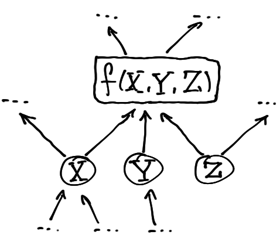

- Umiemy różniczkować funkcje złożone (mnożenie jakobianów) jak policzyć jakobian, skoro funkcja operuje na tablicach, a nie wektorach?
  - potrzeba najpierw rozwinąć wszystkie wejścia
  - skleić je w jeden wektor
  - niech funkcja $f$ przekształci je w rozwinięte wyjście
  - Z reguły to podejście jest niepraktyczne, więc będziemy starali się działać sprytniej.

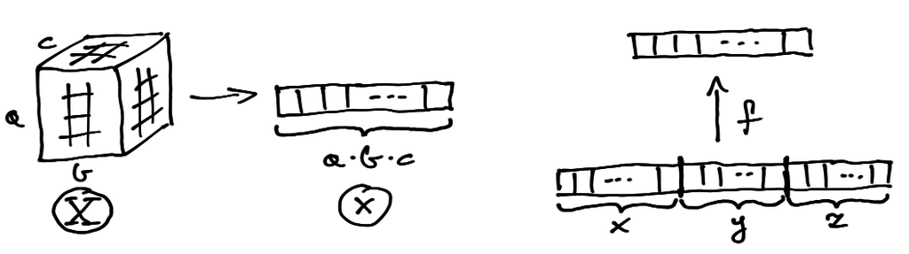

## Cel algorytmu

- Mamy (dane, parametry modelu), który chcemy podać do grafu.
  - na jego podstawie obliczamy wartość funkcji kosztu, reprezentowaną przez wierzchołek $L$
  - dla każdego wierzchołka typu input chcemy obliczyć gradient funkcji kosztu po tym wierzchołku, w punkcie wyznaczonym przez podane na input wartości liczbowe.
- gradienty będziemy oznaczali literą $\delta$.
  - chcemy aby w każdym wierzchołku typu input obliczona została tablica liczb $\delta$
    - jej wymiary są zgodne z podaną na input tablicą wartości liczbowych.
  - można policzyć gradienty również po innych wierzchołkach leżąc na drodze pomiędzy inputami a wierzchołkiem $L$
    - to umożliwi nam obliczenie gradientów inputów.
- gdzie liczymy gradienty?
  - w wierzchołkach wejść to po prostu odpowiednie podawane wartości
  - w pozostałych na podstawie inputu trzeba obliczyć i zapamiętać ich wartości liczbowe
- Podsumowując chcemy
  1. obliczyć i zapamiętać wartości liczbowe wszystkich wierzchołków od wejścia do funkcji kosztu
  2. w tych wierzchołkach obliczyć wartości gradientu funkcji kosztu $\delta$
  3. zwrócić gradienty policzone w wierzchołkach typu input, a w szczególności w wierzchołkach opisujących parametry modelu
  - uczymy model gradientowo

## Przykład

- Regresja liniowa. Naszym zadaniem jest dopasowanie prostej do $N$-elementowego zbioru punktów treningowych $(x_n, y_n)$.

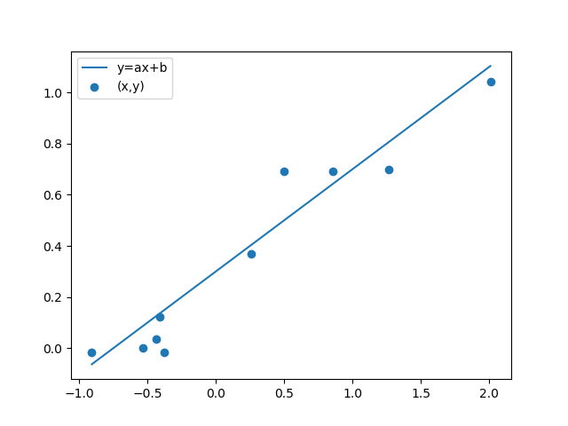

  - Równanie prostej to $\widehat{y} = ax + b$.
  - Niech $\mathbf{x}$ oznacza wektor złożony ze wszystkich $x_n$, natomiast $\mathbf{y}$ wektor wszystkich $y_n$.
  - Funkcję kosztu definiuje się jako $L(a,b) = \dfrac{1}{N}\sum_{n=1}^N (ax_n+b-y_n)^2$.

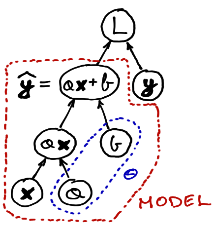

  - Dwuelementowy wektor $\theta=(a,b)$ to parametry modelu.

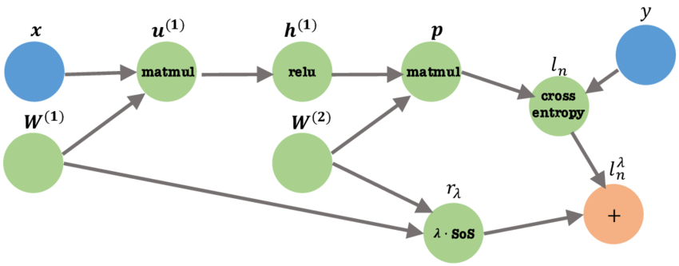

## Backpropagation

- **Node** weźmy dowolny wierzchołek, który opisuje funkcję $f$.
  - jej wejście to ciąg tablic $X_1, \ldots, X_K$
  - wyjście to tablica $Y$. Wierzchołek w grafie musi implementować dwie metody
- **Forward pass** to po prostu implementacja funkcji $f$
  - Metoda przyjmuje $X_1, \ldots, X_K$ i zwraca $Y$
- **Backward pass** metoda przyjmuje $X_1, \ldots, X_K$ oraz $\delta_Y$ i zwraca $\delta_{X_1}, \ldots, \delta_{X_K}$
  - tablica $\delta_Y$ ma takie same wymiary jak $Y$ i przechowuje gradient $L$ po $Y$.
  - metoda ma obliczyć i zwrócić gradient $L$ po inputach. Jak?
    - niech $x$ będzie pewnym elementem tablicy $X_k, k\in\{1,\ldots,K\}$.
      - trzeba sprawdzić, jaki ma on wpływ na wszystkie elementy outputu (odpowiednia pochodna cząstkowa funkcji $f$)
      - przemnożyć je przez odpowiadające elementy $\delta_Y$ i zsumować
        - w ten sposób policzymy, jak łącznie wpływa on na $L$ za pośrednictwem $f$
      - uzyskaną wartość wpisujemy w odpowiednie miejsce tablicy $\delta_{X_k}$.
      - powtarzamy dla wszystkich elementów $X_k$, a następnie dla wszystkich $k$.
  - wartości $X_1, \ldots, X_K$ są potrzebne — pochodna cząstkowa jest funkcją i musi być liczona w punkcie.
  - dla różnych $X_1, \ldots, X_K$ wpływ tego samego wejścia na pewne wyjście może się różnić
    - funkcja $f$ w różnych miejscach swojej dziedziny ma inne liniowe przybliżenie

#### Przykład: numpy.multiply

- Niech $f$ oznacza funkcję, która przyjmuje dwie tablice (tego samego rozmiaru) $X_1, X_2$ i zwraca ich iloczyn element-wise $Y$.
  - Niech $x_1\in{}X_1, x_2\in{}X_2, y\in{}Y, \delta_y\in{}\delta_Y$ (odpowiednie), które mają te same współrzędne, co $x_1$ w $X_1$.
  - z definicji $f$ zachodzi $y = x_1 x_2$
  - także $x_1, x_2$ nie mają wpływu na pozostałe elementy $Y$
  - w takim razie $$ \delta_{x_1} = \dfrac{\partial L}{\partial y}(y)\cdot \dfrac{\partial y}{\partial x_1}(x_1, x_2) = \delta_y \cdot x_2 $$ $$ \delta_{x_2} = \dfrac{\partial L}{\partial y}(y)\cdot \dfrac{\partial y}{\partial x_2}(x_1, x_2) = \delta_y \cdot x_1 $$

import numpy as np def forward_pass(X1, X2): assert X1.shape == X2.shape Y = np.multiply(X1, X2) return Y def backward_pass(dY, X1, X2): assert X1.shape == X2.shape == dY.shape dX1 = np.multiply(dY, X2) dX2 = np.multiply(dY, X1) return dX1, dX2

- Jeśli np. tablice $X_1, X_2, Y$ mają rozmiar $(4,3)$, to jakobian $f$ ma rozmiar $(12,24)$, przy czym jedynie 24 z 288 elementów jakobianu jest niezerowych (bo na każdy $y$ mają niezerowy wpływ tylko dwie rzeczy).
  - Widzimy, że znacznie łatwiej jest zaimplementować backward pass bez mnożenia explicite $\delta_Y$ przez jakobian.
- **Graph**
  1. Wprowadź do grafu obliczeń zbiór treningowy oraz bieżące parametry modelu.
  2. Forward pass: przelicz po kolei wszystkie funkcje (wierzchołki) w grafie, aż do momentu uzyskania wartości funkcji kosztu. Zapamiętaj w każdym pośrednim wierzchołku obliczone wartości - wraz z inputem grafu będą one potrzebne do policzenia pochodnej.
  3. Ustaw $\delta_L = 1$. (dlaczego?)
  4. Dla każdego wierzchołka $W$:
  5. Niech $V_1, \ldots, V_K$ będą wszystkimi wierzchołkami, których inputem jest $W$.
  6. Dla każdego wierzchołka $V_k$ wykonaj krok 4. rekurencyjnie - oblicz i zapisz $\delta_{V_k}$.
  7. Dla każdego wierzchołka $V_k$ wywołaj jego metodę backward pass (użyj zapisanych wartości $\delta_{V_k}$ oraz warości inputów zapamiętanych w kroku 2.). Zapamiętaj wszystkie $\delta_W^k$.
  8. Zsumuj $k$ zapamiętanych tablic $\delta_W^k$, zapisz sumę jako $\delta_W$. (dlaczego suma?)

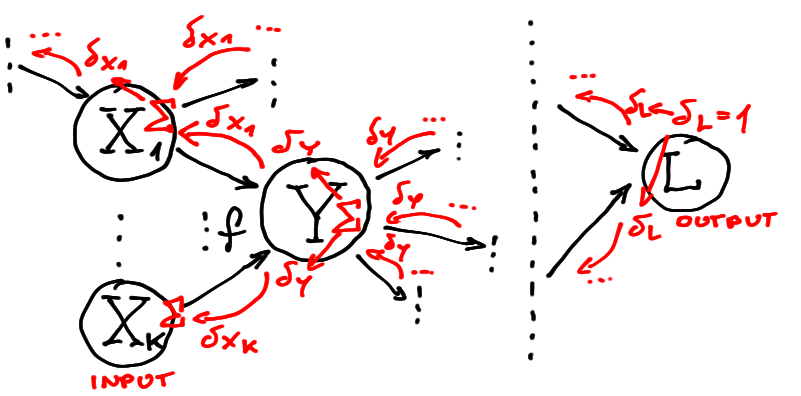

- **Training loop**
  - Uczenie przebiega w pętli.
  - Wykonujemy pełny forward pass, a następnie backward pass.
  - Delty parametrów modelu (gradient funkcji kosztu) przekazujemy do optimizera.
  - Optimizer oblicza nowe wartości parametrów, które użyjemy w następnym kroku.
  - Uczenie kończymy np. po określonej liczbie kroków lub po osiągnięciu satysfakcjonującej wartości funkcji kosztu.

### autograd

- w praktyce wszystkie gradienty są obliczane automatycznie
- wystarcza do tego zestaw podstawowych informacji oraz implementacja reguły łańcuchowej
- pakiet `torch.autograd` (czy innej implementacji)